### **Introduction**

Domestic policy in any given country can be considered one of the main determinants of environmental degradation, though attribution can be difficult to specify due to the complexity of coupled human-environmental systems, as well as local and international markets that drive resource extraction. However, this has not prevented attempts at doing so; the ability to distinguish the effects of policy on natural resource availability would be an incredibly valuable tool for law makers who are genuinely concerned for their country’s environment and interested in refining conservation methods to be as efficient and effective as possible. One place where this is particularly true is in Brazil as it concerns Amazonian deforestation.

The Amazon rainforest is often referred to as “The Lungs of the Earth” because it is the largest rainforest in the world and is responsible for massive carbon sequestration and oxygen generation. It is also one of the most biodiverse places on the planet and even houses many uncontacted indigenous people, though in the western Brazilian Amazon this is becoming less so (*Finer et al, 2008*). As extinction and climate concerns mount, so too do concerns about this forest, which is well-known for massive deforestation. From the 1960’s to 2008 the Amazon lost an incredible 15% of its total forested area, and that number has been growing since (*Barreto and Silva, 2010*). As seen below, deforestation rates have fluctuated significantly with peaks in 1995 and 2004. Recently, beginning around 2014, following a period of the lowest rates in decades, deforestation has begun to pick up speed once again.

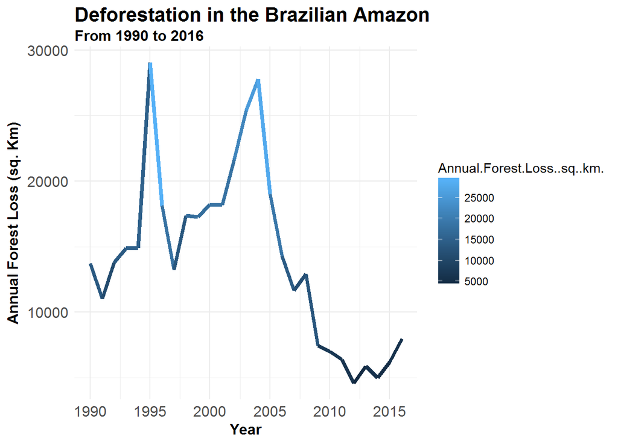

Figure 1. Data is from Mongabay.org (Butler, 2017).

However, this slight resurgence in forest loss rates may not accurately depict the current reality, only one year later. Because of recent political upheaval in Brazil and concommitant, wholesale, shifts in environmental policy deforestation in the Amazon is once again at the forefront of conservation and climate concerns.

#### **Policy, Markets, and Deforestation**

The afformentioned attempts at quantifying the causes of forest loss in the Brazilian Amazon are numerous and identify a clear link with policy and market forces. Attribtution methodolodies range from simple economic correlations to complex, statistical spatial statistics. For instance, Soares-Filho et al. review and critique numerous methods of quantifying the effects government imposed protected areas (PAs) on deforestation rates, then apply their own pair-wise comparison method using what they call the “adjusted odds ratio of deforestation”. This is a Bayesian approach which incorporates a spatial component that enables both broad and local analysis of the effects of PAs. They found that, between 2004 and 2006, PAs accounted for 37% percent of deforestation rate reductions (*Soares-Filho et al, 2010*).

It is clear that governmental policies significantly influence loss rates, though market forces beyond that realm of control are also incredibly important. Most of these sorts of attribution studies paint a rather specific image of the process. Nepstad et al, though, provide a useful narrative of sequential events that correlate rather well with observed patterns dating all the way back to the early 1990’s and up to 2013.

Though deforestation in this region has occured since the 1960’s, it wasn’t until the 1990’s that loss rates became a significant concern. This is described as a result of increased technological capability, globalization, and subsequent international demand for commodities like soybean, beef and timber, as mentioned above. Recognizing this development as a severe resource conservation problem, the Brazilian government enacted what is called “The Forest Code”, or FC, which served as the main forest protection policy throughout the nineties. The FC, initially, legally restricted any single private enterprise from clearing more than 50% of the forest on their property, requiring that the rest be managed as a forest reserve. It was important, but wasn’t sufficiently effective as loss rates continued to rise through the first half this decade. The law was intensified in 1996 to require that 80% of each property’s forest be reserved. While this can be considered progressive policy, it was impossible to fully enforce. The updated Forest Code lost credibility and probably would not have been successful alone. However, when coupled with further laws and other mixed market-regulatory strategies the FC would help to significantly undermine the attraction of the market; forest loss rates peaked around the time of that adjustment and have not reached the same level since. The lull would not last for long, however, as deforestation picked up significantly only a few years later.

In the mid 2000’s several events led to a distinct reduction in deforestation rates that would last until the mid-2010’s. It was centered around increased government enforcement of regulations and a collapse in the price of soybeans. Monitoring of deforestation was significantly improved in this time frame and, with policies such as the “Plan for the Protection and Control of Deforestation in the Amazon”, it become legally dangerous to break forest protection laws. On the market side, in addition to the fall in soybean price, international buyers began to avoid soy produced on deforested Amazonian land. These events also corresponded with a large expansion of protected areas, particularly those inhabited by indigenous people .

In the early 2010’s market prices and sentiments began to rebound and soy and cattle production did with them. In response the government tried new approaches; rescaling proctective regulations from the farm level to the state level while improving mapping at the property level, restricting credit for farms in high deforestation areas, delaying paved road construction, and implementing a system of incentives for farmers who adopt protective practices with assistance from items such as The Amazon Fund, a one billion dollar contribution from Norway (*Nepstad et al, 2014*).

Supply chain interventions via mechanisms such as zero-deforestation aggreements with slaughter houses further undermined the rebound in commodity prices and helped to bring deforestation to a long-term low point in 2012 (*Gibbs et al, 2016*). However, later in 2012 a new Forest Code was created, retroactively pardoning large producers who acted illegally before the summer of 2008 and adjusting pathways necessary for compliance with the law in a way that provided legal avenues for destructive practices. A slight increase in deforestation would be seen following this event with a steeper increase following 2014 as companies learned to take more advantage of the shift in regulation. This change in protective policy, however, would pale in comparison to the full scale overhaul of government policy that would occur after a sudden change in executive governance in the summer of 2016.

#### **Political Coup and Wholesale Regulatory Overhaul**

In August of 2016, with the backing of state media and the Brazilian Democratic Movement Party, President Dilma Rousseff was ousted via congressional impeachment in what is considered by many to be a political coup. Michel Temer, the vice president under Rousseff, assumed power and immediately began to implement neoliberal reforms such as the privatization of state functions, severe budgetary restrictions on social welfare programs and, importantly, the gutting of environmental protection law (*Vieira, 2016*). Concessions to large agribusinesses are still central to this new agenda, as Temer and his newly appointed cabinet lift restrictions on farming and mining in protected areas such as national parks and bio-reserves that were key to the successful forest protection initiatives of the past (*Cowie, 2017*). Within months of the transition, other laws were also passed to retroactively pardon past illegal land grabs, renege on indigenous land right agreements, and offer debt relief to the agricultural sector(*Maisonnave, 2017*).

While this spells trouble for the Amazon, it does provide an interesting opportunity to examine the effects of policy on the environment. It is rare to observe such a rapid and wholesale shift in environmental policy. Because this event is so significant we would expect that 2017 deforestation rates will by far out pace any year since 2012, despite the increase since the new Forest Code was enacted. In order to check this assumption, and gain a general understanding of the magnitude of the effects of this political change on the forest, satellite-based monitoring techniques can be used.

#### **Forest Monitoring**

One of the elements of a successful forest protection program is accurate and timely monitoring. One world-wide program that is often used for this is called Forest Monitoring for Action (FORMA) which uses NASA’s Moderate Resolution Imaging Spectroradiometer (MODIS) to provide 500 meter resolution sub-monthly analyses of forest loss rates (*Wheeler et al, 2014*). The Brazilian government employs another method using a program called PRODES (Programa Despoluição de Bacias Hidrográficas) to create country scale deforestation figures. This is based on Landsat, which has a much finer resolution at 30 meters. The PRODES monitoring product has enabled Brazil to generate the longest active forest monitoring data in the world (*Milodowski et al, 2017*). Another product is called Global Forest Watch, referred to as GFW from here on (*Hansen et al, 2013*). This is another Landsat based product, but it uses a slightly different methodology than PRODES and makes estimates for the entire globe. GFW, naturally, uses a heavily automated classification algorithm to distinguish between tree-cover and other landcover type while PRODES is small enough in scale to enable a quasi-manual method that can incorporate nuance.

Milodowski et al. compare the accuracy of each of these products using supervised classification with images from the RapidEye satellite which provides a thouroughly modern 5-meter resolution. The study period was between 2009 and 2015 and included two sites, one in south Acre State and the other Rondonia. Expectedly, the coarser FORMA was found to be the least accurate, but GFW was actually found to be more accurate than PRODES. In this case, the consistency of automation appears to outweigh the potential precision from a more hands on approach (*Milodowski et al, 2017*).

GFW is a well-known and used source for world wide deforestion rates. Considering this and the results of the accuracy assessment above we chose to use GFW figures for background loss rates. Rates over time as calculated by this organization match well with observations in the literature, but at the time of this writing they have not yet quantified the 2017 figures, and won’t until early 2018. While under normal circumstances one might be patient enough to wait for these results, when considering the link between governance and deforestation and the importance of this region, this political situation breeds curiousity worldwide. It has been more than a year since the coup and the appropriate Landsat data is available, therefore it is the aim of this study to update forest loss rates, compare them to recent years, and check our expectation that they will be significantly higher than in any recent year. While we lack the means to fully access and reproduce the GFW methodology, for this study we develop our own and validate the results with know GFW years.

### **Data**

To quantify yearly deforestation rates a sample area in Para, Brazil was chosen and Landsat 8 Operational Land Imager data was obtained for the years 2013 to 2017 from the USGS Earth Explorer portal. Para state is considered to have some of the highest deforestation rates in the country (*Lorena & Lambin, 2009*). It also has the largest cattle herd in the country, accounting for 20% of beef exports, which makes deforestation there particularly sensitive to pro-agribusiness policies (*Gibbs et al, 2016*). This area is in the South of Para, adjacent to and east of the Parque Nacional do Rio Novo, and was chosen based on several criteria. Most importantly, the area exhibited classic signs of deforestation from satellite imagery; a main road with branching patterns of tree loss and bare land. This is often referred to as a “fish-bone” pattern of deforestation, common in Para and associated both with private interprise and government sponsored programs called “projetos de colonização” (PICs) that date back to the 1970s and encourage settlement of small-land holders along major highways and roads (*Arima et al, 2016*). It was also chosen because it is directly adjacent to a national park which, as previously discussed, is considered a highly vulnerable area following the recent policy shifts. This location also provided consecutive years of relatively cloud free, and therefore rare, imagery in roughly the same season, Brazilian winter in this case. Considering the criteria, this location was considered an ideal sample from which to infer deforestation patterns in the Brazilian Amazon as a whole.

GFW data was obtained as simple yearly areas of new deforestation within the same study area using their map and data portals. While GFW data extends back to 2001, we chose 2012 as the start date. Deforestation rates are too volatile on a longer time frame, and this date corresponds with the new Forest Code and a general increase in background loss rates. Unfortunately, we only had Landsat data back to 2013. Landsat 7 data would have been suitable, but a failure in that satellite’s scan line corrector left gaps in images generated after May of 2003 (*Storey et al, 2017*).

[figure not shown]

### **Methods**

The general methodology was to quantify Amazonian deforestation rates in Brazil up the most recent date possible, compare the results up to 2016 with Global Forest Watch data for validation, and then compare the 2017 rates with prior years to see if a significant change occured.

The next steps were to account for discrepencies in the data, generate yearly 3-band composite images with high contrast at the forest edge, use unsupervised k-means clustering to classify tree and non-tree landcover types, apply an aggregate cloud mask, count newly deforested image pixels each year, and then take that number as a percentage of the overall area.

The band combination of shortwave-infrared (SWIR), near-infrared (NIR), and red was found to provide the contrast needed. For each year a composite of these bands was generated. Each of these composites was then adjusted for slight shifts in extents, which was necessary to perform raster calculations. They were also, for comparison purposes, reprojected from the local UTM projection to the Web Mercator projection system that Global Forest Watch uses. To account for cloud cover that couldn’t be avoided from the inital site selection the cloud layers from each yearly dataset were merged into one layer and applied to each individual image in the classification step. In this way, only the areas that were exposed in every year were used in the calculations. This omitted about 129,000 ha out of 2,254,847 ha, or roughly 6 percent, of the total area.

Unsupervised K-means clustering was used to classify forest cover because each pixel in the composite is comprised of three values, which made it difficult to determine a simple threshold. Also, because the images were taken at slightly different points in the winter and because of possible atmospheric effects, forest pixel values were not completely consistent from year to year. K-means, though, classifies each image according to the data distributions of that image itself and accounts for these discrepencies in this way. The k-means clustering step was performed with 2 clusters, 3 starting points, and 25 iterations. Many combinations of parameters were tried, but this combination was found to be computationally feasible without significantly altering the final product.

An issue with other remotely sensed methods as well as k-means clustering is the classification of crop/grazing land as forest. Several different numbers of clusters were attempted to see if the unsupervised algorithm could distinguish the class of landcover from forest, but it was unsuccessful at doing so. In order to account for this, the 2 cluster approach was chosen and, assuming that new forest growth could not occur within the few years of the study period, each year’s total deforested area was used as a mask for the next year’s image. In this way only newly deforested land is counted. This method will initially miss unharvested land, but gradually improves as more and more harvested land is added to the known loss mask. While our study period is limited due the relatively recent launch of Landsat and a scan-line failure in Landsat 7, it appears as though one or two years will generally suffice to obtain an accurate mask.

The output was expressed as percentage of the total study area not covered by the cloud layer. Percentages were used both because the total area in GFW is slightly different than ours following the cloud masking step and we are using this area as a sample of the whole forest. The percentages of loss were calculated by of the total area and not the forest area because that gives a consistent and interpretable results. Percentages of total forest loss might express artificially elevated rates in a limited study area as the overall forest area diminishes. Landsat 8 OLI data only extends back to 2013, while Global Forest Watch extends much further back. However, Landsat 8 provides recent images, so 2016-2017 data was available where Global Forest Watch was lacking.

### **Results**

While the results are limited by the availability of data, they do indicate that our method was, at least for short term analysis, on par with that of GFW. The first year of our results is actually 2015. This is because there is no information on deforestation change in our first year, 2013, and the next year had not yet been fully calibrated. Because the k-means clustering algorithm will categorize non-harvested crop land as forest, the first harvest will be interpreted as deforestation. However, following the first two years of the masking process our number aligned with surprising accuracy to those of GFW, as can be seen below.

#### **Kmeans cluster results 2013 - 2017**

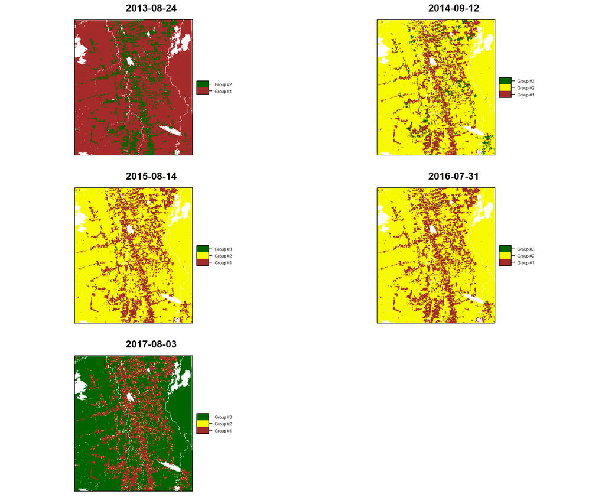

Figure 3. Time series of kmeans groupings. Year one only has two groups because it is the first year while each subsequent year has forest, non-forest, and recent deforestation in random groups. These are identified by the relative number of pixels in each group because of the random assignment of groups

#### **Percentage loss by year and method**

| Year | Global Forest Watch (% total area) | Landsat 8 OLI Clustered 6,5,4 Composite (% total area) |
| --- | --- | --- |
| **2012** | 1.51 | **NA** |
| **2013** | 0.63 | **NA** |
| **2014** | 1.07 | **3.82*** |
| **2015** | 0.58 | 0.57 |
| **2016** | 0.62 | 0.65 |
| **2017** | **NA** | 2.67 |

* Uncalibrated year

Table 1. Percentages are expressed as the amount of new, yearly deforestated out of the total area within the study site.

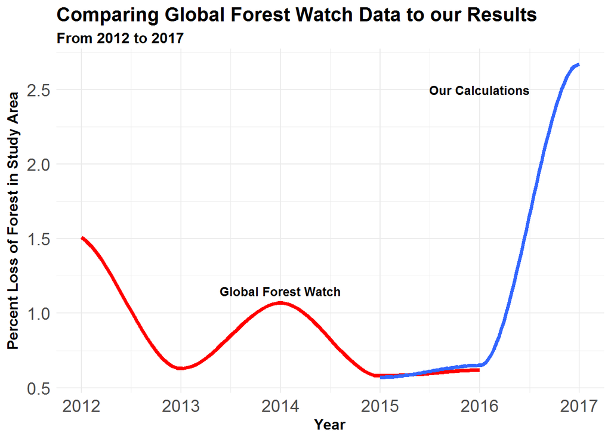

Figure 4. Line graph comparison of our yearly deforestation rates with the rates calculated by Global Forest Watch from 2012 to 2017 witn our study site in the State of Para. Note that Global Forest Watch calculations are not available yet for 2017. Rates are caluclated as percent of total area.

### **Conclusions**

While our results cannot be considered conclusive, they do match the general expected trend for 2017 and Global Forest Watch’s past calculations. However, the magnitude of the increase in deforestation was certainly not expected. If this area is genuinely indicative of nation-wide trends we are witnessing some of the highest Amazon rainforest loss in over a decade.

This is also not a specific attribution study, but it does indicate the degree to which government policy affects the preservation of natural areas and resources. There was no indication in recent news or research articles that commodity prices rose coincidentally with the political shift in Brazil in the summer of 2016. With that being said, the most salient conclusion that can be drawn from this study is that, without government regulation and intervention, unbridled market forces will wreck havoc on the Amazon. One might infer that this trend holds true for most other resources as well and while this would come as no surprise to natural resource managers and researchers, perhaps the magnitude and rapidity of these findings will help to underscore the importance of well planned and administered environmental policy.

### **References**

Arima, E. Y., Walker, R. T., Perz, S., & Souza, C. 2016. Explaining the fragmentation in the Brazilian Amazonian forest. Journal of Land Use Science, 11(3), 257-277. https://doi.org/10.1080/1747423X.2015.1027797

Barreto, P, and D Silva. 2010. “Will Cattle Ranching Continue to Drive Deforestation in the Brazilian Amazon ?” Imazon - Instituto Do Homem E Meio Ambiente Da Amazônia, no. November: 23. doi:10.1017/CBO9781107415324.004.

Butler, R.A. 2017. Mongabay.com. Retrieved 11-16-2017, from http://www.mongabay.com/

Cowie, Sam. 2017.“Nature under attack in Brazil”.Deutsche Welle - Environment.Aug 14, 2017.

Finer, Matt, Clinton N Jenkins, Stuart L Pimm, Brian Keane, and Carl Ross. 2008. “Oil and Gas Projects in the Western Amazon: Threats to Wilderness, Biodiversity, and Indigenous Peoples.” doi:10.1371/journal.pone.0002932.

Gibbs, H. K., Munger, J., L’Roe, J., Barreto, P., Pereira, R., Christie, M., . Walker, N. F. 2016. Did Ranchers and Slaughterhouses Respond to Zero-Deforestation Agreements in the Brazilian Amazon? Conservation Letters, 9(1), 32-42. https://doi.org/10.1111/conl.12175

Hansen, M C, P. V. Potapov, R. Moore, M. Hancher, S. A. Turubanova, A. Tyukavina, D. Thau, et al. 2013. “High-Resolution Global Maps of 21st-Century Forest Cover Change.” Science 342 (6160): 850-53. doi:10.1126/science.1244693.

Hargrave, Jorge, and Krisztina Kis-Katos. 2013. “Economic Causes of Deforestation in the Brazilian Amazon: A Panel Data Analysis for the 2000s.” Environmental and Resource Economics 54 (4): 471-94. doi:10.1007/s10640-012-9610-2.

Lorena, R. B., & Lambin, E. F. 2009. The spatial dynamics of deforestation and agent use in the Amazon. Applied Geography, 29(2), 171-181. https://doi.org/10.1016/j.apgeog.2008.09.003

Maisonnave, Fabiano. 2017 “‘Beef caucus’ takes over indigenous policies in Brazil”.Climate Change News. March 17, 2017.

Milodowski, D. T., Mitchard, E. T. A., & Williams, M. 2017. Forest loss maps from regional satellite monitoring systematically underestimate deforestation in two rapidly changing parts of the Amazon. Environmental Research Letters, 12(9). https://doi.org/10.1088/1748-9326/aa7e1e

Nepstad, D., McGrath, D., Stickler, C., Alencar, A., Azevedo, A., Swette, B., . Hess, L. 2014. Slowing Amazon deforestation through public policy and interventions in beef and soy supply chains. Science, 344(6188), 1118-1123. https://doi.org/10.1126/science.1248525

Soares-Filho, Britaldo, Paulo Moutinho, Daniel Nepstad, Anthony Anderson, Hermann Rodrigues, Ricardo Garcia, Laura Dietzsch, et al. 2010. “Role of Brazilian Amazon Protected Areas in Climate Change Mitigation.” Proceedings of the National Academy of Sciences 107 (24): 10821-26. doi:10.1073/pnas.0913048107.

Storey, James, Pasquale Scaramuzza, Gail Schmidt, and Julia Barsi. 2017. “LANDSAT 7 SCAN LINE CORRECTOR-OFF GAP-FILLED PRODUCT DEVELOPMENT.” Accessed December 17. http://www.asprs.org/a/publications/proceedings/pecora16/Storey_J.pdf.

Van Der Werf, G R , D C Morton, R S Defries, J G J Olivier, P S Kasibhatla, R B Jackson, G J Collatz, and J T Randerson. 2009. “CO2 Emissions from Forest Loss.” Nature Geoscience. doi:10.1038/ngeo671.

Vieira, Inacio. 2016.“Brazil’s impeached ex-president dilma rousseff says successor ‘confessed to the coup’”.The Intercept. Sep. 28 2016.

Wheeler, David, Dan Hammer, Robin Kraft, and Aaron Steele. 2014. “Satellite-Based Forest Clearing Detection in the Brazilian Amazon: FORMA, DETER, and PRODES In.” World Resources Institute Issue Brief, 1-24. http://wribrasil.org.br/sites/default/files/forma-issue-brief_1.pdf.